# Ghana earmarked-fund budgets

IMF research project

2026-08-24

This notebook produces six figures on Ghana’s budgeted allocations to earmarked funds. The figures describe nominal budget appropriations and their share of total government expenditure; they do not measure actual transfers, disbursements, or expenditure execution. Each PNG is paired with a CSV containing the exact data used to draw it.

# 1. Load and validate the source workbooks

```r
all_funds_raw <- suppressMessages(
  read_excel(input_paths[["all_earmarked_funds"]], sheet = "Feuil1")
)
exclusive_funds_raw <- suppressMessages(
  read_excel(input_paths[["exclusive_funds"]], sheet = "Feuil1")
)
exclusive_total_raw <- suppressMessages(
  read_excel(input_paths[["exclusive_total"]], sheet = "Feuil1")
)

fund_level_required <- c(
  "budget_year", "fund_key", "fund_label_as_published",
  "budget_ghc", "source_notes", "canonical_fund_label",
  "total_expenditure", "share_of_total_expenditure"
)
exclusive_total_required <- c(
  "budget_year", "direct_earmark_budget_ghc",
  "total_expenditure_ghc", "share_of_total_expenditure"
)

validate_required_columns(
  all_funds_raw, fund_level_required, "earmarked_fund_budgets.xlsx"
)
validate_required_columns(
  exclusive_funds_raw,
  fund_level_required,
  "exclusive_earmark_budgets.xlsx"
)
validate_required_columns(
  exclusive_total_raw,
  exclusive_total_required,
  "total_exclusive_earmarked_fund_budgets.xlsx"
)

validate_numeric_columns(
  all_funds_raw,
  c(
    "budget_year", "budget_ghc", "total_expenditure",
    "share_of_total_expenditure"
  ),
  "earmarked_fund_budgets.xlsx"
)
validate_numeric_columns(
  exclusive_funds_raw,
  c(
    "budget_year", "budget_ghc", "total_expenditure",
    "share_of_total_expenditure"
  ),
  "exclusive_earmark_budgets.xlsx"
)
validate_numeric_columns(
  exclusive_total_raw,
  c(
    "budget_year", "direct_earmark_budget_ghc",
    "total_expenditure_ghc", "share_of_total_expenditure"
  ),
  "total_exclusive_earmarked_fund_budgets.xlsx"
)

all_year_values <- c(
  all_funds_raw$budget_year,
  exclusive_funds_raw$budget_year,
  exclusive_total_raw$budget_year
)
if (any(!is.na(all_year_values) & all_year_values != floor(all_year_values))) {
  stop("A budget-year field contains a non-integer numeric value.")
}

all_transfers_raw <- all_funds_raw %>%
  filter(fund_key == "grants_total")
if (nrow(all_transfers_raw) == 0) {
  stop("No fund_key == 'grants_total' observations were found.")
}
```

## Source coverage and integrity checks

```r
make_validation_row <- function(
  data,
  source_name,
  keys,
  budget_field = "budget_ghc",
  total_fund_field = "fund_key"
) {
  absent_rows <- if ("source_notes" %in% names(data)) {
    is_absent_note(data$source_notes)
  } else {
    rep(FALSE, nrow(data))
  }

  tibble(
    source = source_name,
    years_available = paste(
      sort(unique(data$budget_year[!is.na(data$budget_year)])),
      collapse = "; "
    ),
    n_rows = nrow(data),
    n_funds = if (total_fund_field %in% names(data)) {
      n_distinct(data[[total_fund_field]], na.rm = TRUE)
    } else {
      NA_integer_
    },
    missing_year = sum(is.na(data$budget_year)),
    missing_budget_ghc = sum(is.na(data[[budget_field]])),
    missing_share_of_total_expenditure = sum(
      is.na(data$share_of_total_expenditure)
    ),
    rows_marked_absent = sum(absent_rows),
    explicit_zero_budget_rows = sum(
      data[[budget_field]] == 0 & !absent_rows,
      na.rm = TRUE
    ),
    duplicate_key_groups = duplicate_group_count(data, keys)
  )
}

source_validation <- bind_rows(
  make_validation_row(
    all_funds_raw,
    "earmarked_fund_budgets.xlsx — complete workbook",
    c("budget_year", "fund_key")
  ),
  make_validation_row(
    all_transfers_raw,
    "earmarked_fund_budgets.xlsx — grants_total used in Plots 1–2",
    c("budget_year", "fund_key")
  ),
  make_validation_row(
    exclusive_funds_raw,
    "exclusive_earmark_budgets.xlsx",
    c("budget_year", "fund_key")
  ),
  make_validation_row(
    exclusive_total_raw,
    "total_exclusive_earmarked_fund_budgets.xlsx",
    "budget_year",
    budget_field = "direct_earmark_budget_ghc",
    total_fund_field = ""
  )
)

if (any(source_validation$duplicate_key_groups > 0)) {
  stop("Duplicate year/fund observations make the requested plot grain ambiguous.")
}

exclusive_fund_inventory <- exclusive_funds_raw %>%
  distinct(fund_key, canonical_fund_label) %>%
  arrange(canonical_fund_label)

if (nrow(exclusive_fund_inventory) !=
    n_distinct(exclusive_funds_raw$fund_key)) {
  stop("An exclusive fund_key maps to more than one canonical fund name.")
}

exclusive_zero_audit <- exclusive_funds_raw %>%
  transmute(
    year = as.integer(budget_year),
    fund_key,
    fund_name = canonical_fund_label,
    raw_budget_ghc = budget_ghc,
    raw_share_of_total_expenditure = share_of_total_expenditure,
    source_notes = as.character(source_notes),
    plotting_treatment = case_when(
      is_absent_note(source_notes) ~ "Gap: source note marks observation absent",
      budget_ghc == 0 ~ "Explicit zero: plotted at zero",
      TRUE ~ "Observed positive value"
    )
  ) %>%
  filter(raw_budget_ghc == 0 | is_absent_note(source_notes)) %>%
  arrange(fund_name, year)
```

```r
kable(
  source_validation,
  caption = "Ghana budget source coverage, missingness, and key integrity"
)
```

Ghana budget source coverage, missingness, and key integrity

| source | years_available | n_rows | n_funds | missing_year | missing_budget_ghc | missing_share_of_total_expenditure | rows_marked_absent | explicit_zero_budget_rows | duplicate_key_groups |
| --- | --- | --- | --- | --- | --- | --- | --- | --- | --- |
| earmarked_fund_budgets.xlsx — complete workbook | 2017; 2018; 2019; 2020; 2021; 2022; 2023; 2024; 2025; 2026 | 210 | 21 | 0 | 31 | 0 | 31 | 3 | 0 |
| earmarked_fund_budgets.xlsx — grants_total used in Plots 1–2 | 2017; 2018; 2019; 2020; 2021; 2022; 2023; 2024; 2025; 2026 | 10 | 1 | 0 | 0 | 0 | 0 | 0 | 0 |
| exclusive_earmark_budgets.xlsx | 2018; 2019; 2020; 2021; 2022; 2023; 2024; 2025; 2026 | 63 | 7 | 0 | 0 | 0 | 2 | 2 | 0 |
| total_exclusive_earmarked_fund_budgets.xlsx | 2018; 2019; 2020; 2021; 2022; 2023; 2024; 2025; 2026 | 9 | NA | 0 | 0 | 0 | 0 | 0 | 0 |

```r
cat(
  "Exclusive-earmark funds found:",
  n_distinct(exclusive_funds_raw$fund_key), "\n"
)
```

```
## Exclusive-earmark funds found: 7
```

```r
kable(
  exclusive_fund_inventory,
  caption = "Exclusive-earmark funds represented in the source workbook"
)
```

Exclusive-earmark funds represented in the source workbook

| fund_key | canonical_fund_label |
| --- | --- |
| energy_fund | Energy Fund / petroleum-related funds |
| gacl | Ghana Airport Company Ltd. |
| exim_edl | Ghana EXIM Bank / Export Development Levy |
| getf | Ghana Education Trust Fund |
| nhf | National Health Fund |
| pwrf | Plastic Waste Recycling Fund |
| road_fund | Road Fund |

```r
kable(
  exclusive_zero_audit,
  caption = paste(
    "Zero and source-absent observations.",
    "Rows marked absent are plotted as gaps; explicit zeros remain at zero."
  )
)
```

Zero and source-absent observations. Rows marked absent are plotted as gaps; explicit zeros remain at zero.

| year | fund_key | fund_name | raw_budget_ghc | raw_share_of_total_expenditure | source_notes | plotting_treatment |
| --- | --- | --- | --- | --- | --- | --- |
| 2019 | pwrf | Plastic Waste Recycling Fund | 0 | 0 | absent | Gap: source note marks observation absent |
| 2024 | pwrf | Plastic Waste Recycling Fund | 0 | 0 | 0 | Explicit zero: plotted at zero |
| 2025 | pwrf | Plastic Waste Recycling Fund | 0 | 0 | 0 | Explicit zero: plotted at zero |
| 2026 | pwrf | Plastic Waste Recycling Fund | 0 | 0 | absent | Gap: source note marks observation absent |

Two Plastic Waste Recycling Fund rows are numerically stored as zero but marked `absent` in the source notes. For plotting only, those observations are treated as missing and shown as gaps. The raw zero fields remain in the exported CSVs. The separately reported 2024 and 2025 zeros are explicit source values and remain plotted at zero.

# 2. Prepare the six plot datasets

```r
all_transfers_base <- all_transfers_raw %>%
  transmute(
    year = as.integer(budget_year),
    fund_key,
    fund_name = canonical_fund_label,
    fund_label_as_published,
    budget_ghc,
    total_expenditure_ghc = total_expenditure,
    share_of_total_expenditure
  ) %>%
  arrange(year)

exclusive_total_base <- exclusive_total_raw %>%
  transmute(
    year = as.integer(budget_year),
    budget_ghc = direct_earmark_budget_ghc,
    total_expenditure_ghc,
    share_of_total_expenditure
  ) %>%
  arrange(year)

if (any(is.na(all_transfers_base$year)) ||
    any(is.na(exclusive_total_base$year))) {
  stop("Annual-total year is missing; an x-axis position cannot be assigned.")
}

common_share_y_max <- ceiling(
  100 * max(
    all_transfers_base$share_of_total_expenditure,
    exclusive_total_base$share_of_total_expenditure,
    na.rm = TRUE
  ) / 5
) * 5 / 100

common_amount_y_max_billions <- ceiling(
  max(
    all_transfers_base$budget_ghc,
    exclusive_total_base$budget_ghc,
    na.rm = TRUE
  ) / 1000000000 / 10
) * 10

all_transfers_share_data <- all_transfers_base %>%
  add_extreme_annotations("share_of_total_expenditure") %>%
  mutate(y_axis_max = common_share_y_max)

exclusive_total_share_data <- exclusive_total_base %>%
  add_extreme_annotations("share_of_total_expenditure") %>%
  mutate(y_axis_max = common_share_y_max)

all_transfers_amount_data <- all_transfers_base %>%
  mutate(
    budget_ghc_billions = budget_ghc / 1000000000,
    year_role = if_else(year == max(year), "Latest year", "Earlier year"),
    latest_value_label = if_else(
      year_role == "Latest year",
      paste0("GH¢", number(budget_ghc_billions, accuracy = 0.1), "bn"),
      NA_character_
    ),
    y_axis_max_billions = common_amount_y_max_billions
  )

exclusive_total_amount_data <- exclusive_total_base %>%
  mutate(
    budget_ghc_billions = budget_ghc / 1000000000,
    year_role = if_else(year == max(year), "Latest year", "Earlier year"),
    latest_value_label = if_else(
      year_role == "Latest year",
      paste0("GH¢", number(budget_ghc_billions, accuracy = 0.1), "bn"),
      NA_character_
    ),
    y_axis_max_billions = common_amount_y_max_billions
  )
```

```r
exclusive_funds_observed <- exclusive_funds_raw %>%
  transmute(
    year = as.integer(budget_year),
    fund_key,
    fund_label_as_published,
    fund_name = canonical_fund_label,
    source_notes = as.character(source_notes),
    raw_budget_ghc = budget_ghc,
    total_expenditure_ghc = total_expenditure,
    raw_share_of_total_expenditure = share_of_total_expenditure,
    is_source_absent = is_absent_note(source_notes),
    budget_ghc = if_else(is_source_absent, NA_real_, raw_budget_ghc),
    share_of_total_expenditure = if_else(
      is_source_absent,
      NA_real_,
      raw_share_of_total_expenditure
    )
  )

exclusive_years <- seq(
  min(exclusive_funds_observed$year, na.rm = TRUE),
  max(exclusive_funds_observed$year, na.rm = TRUE)
)
fund_lookup <- exclusive_funds_observed %>%
  distinct(fund_key, fund_name)

# Completing the year grid makes a genuinely absent annual row visible as a
# gap instead of connecting the surrounding observations.
exclusive_funds_complete <- expand_grid(
  fund_key = sort(unique(exclusive_funds_observed$fund_key)),
  year = exclusive_years
) %>%
  left_join(exclusive_funds_observed, by = c("fund_key", "year")) %>%
  select(-fund_name) %>%
  left_join(fund_lookup, by = "fund_key")

fund_display_rules <- exclusive_funds_complete %>%
  group_by(fund_key, fund_name) %>%
  summarise(
    total_budget_ghc = sum(budget_ghc, na.rm = TRUE),
    max_budget_ghc = max(budget_ghc, na.rm = TRUE),
    .groups = "drop"
  ) %>%
  arrange(desc(total_budget_ghc), fund_name) %>%
  mutate(
    fund_order = row_number(),
    display_unit = if_else(
      max_budget_ghc >= 1000000000,
      "GH¢ billions",
      "GH¢ millions"
    ),
    unit_divisor = if_else(
      display_unit == "GH¢ billions",
      1000000000,
      1000000
    ),
    fund_panel_share = str_wrap(fund_name, width = 27),
    fund_panel_amount = paste0(
      str_wrap(fund_name, width = 27),
      "\n(", display_unit, ")"
    )
  )

fund_panel_share_levels <- fund_display_rules %>%
  arrange(fund_order) %>%
  pull(fund_panel_share)
fund_panel_amount_levels <- fund_display_rules %>%
  arrange(fund_order) %>%
  pull(fund_panel_amount)

exclusive_funds_plot_data <- exclusive_funds_complete %>%
  left_join(fund_display_rules, by = c("fund_key", "fund_name")) %>%
  mutate(
    budget_display = budget_ghc / unit_divisor,
    fund_panel_share = factor(
      fund_panel_share,
      levels = fund_panel_share_levels
    ),
    fund_panel_amount = factor(
      fund_panel_amount,
      levels = fund_panel_amount_levels
    ),
    plotting_treatment = case_when(
      is_source_absent ~ "Gap: source note marks observation absent",
      budget_ghc == 0 ~ "Explicit zero: plotted at zero",
      is.na(budget_ghc) ~ "Gap: missing observation",
      TRUE ~ "Observed value"
    )
  ) %>%
  arrange(fund_order, year)

exclusive_fund_share_y_max <- ceiling(
  max(
    exclusive_funds_plot_data$share_of_total_expenditure,
    na.rm = TRUE
  ) * 100
) / 100

exclusive_fund_share_data <- exclusive_funds_plot_data %>%
  mutate(shared_y_axis_max = exclusive_fund_share_y_max)

exclusive_fund_amount_data <- exclusive_funds_plot_data
```

# 3. All earmarked funds — annual total

## All earmarked-fund transfers as a share of expenditure

```r
kable(all_transfers_share_data)
```

| year | fund_key | fund_name | fund_label_as_published | budget_ghc | total_expenditure_ghc | share_of_total_expenditure | annotation_role | annotation_label | annotation_hjust | y_axis_max |
| --- | --- | --- | --- | --- | --- | --- | --- | --- | --- | --- |
| 2017 | grants_total | Grants to other government units | Grants to Other Government Units | 9730834660 | 54394794956 | 0.1788928 | First | 17.9% | -0.1 | 0.25 |
| 2018 | grants_total | Grants to other government units | Grants to Other Government Units | 12046035095 | 61151810604 | 0.1969857 | NA | NA | 0.5 | 0.25 |
| 2019 | grants_total | Grants to other government units | Grants to Other Government Units | 13798464237 | 72710768495 | 0.1897719 | NA | NA | 0.5 | 0.25 |
| 2020 | grants_total | Grants to other government units | Grants to Other Government Units | 15635154175 | 84508862873 | 0.1850120 | NA | NA | 0.5 | 0.25 |
| 2021 | grants_total | Grants to other government units | Grants to Other Government Units | 18081390564 | 110050226597 | 0.1643013 | NA | NA | 0.5 | 0.25 |
| 2022 | grants_total | Grants to other government units | Grants to Other Government Units | 26828362838 | 135629030822 | 0.1978069 | NA | NA | 0.5 | 0.25 |
| 2023 | grants_total | Grants to other government units | Grants to Other Government Units | 30078760145 | 190996541127 | 0.1574833 | Minimum | 15.7% | 0.5 | 0.25 |
| 2024 | grants_total | Grants to other government units | Grants to Other Government Units | 39588951873 | 226680899509 | 0.1746462 | NA | NA | 0.5 | 0.25 |
| 2025 | grants_total | Grants to other government units | Grants to Other Government Units | 54566582264 | 270924147254 | 0.2014091 | NA | NA | 0.5 | 0.25 |
| 2026 | grants_total | Grants to other government units | Grants to Other Government Units | 63554249517 | 302455735488 | 0.2101274 | Last / Maximum | 21.0% | 1.1 | 0.25 |

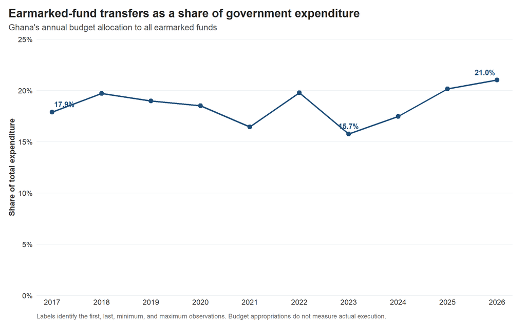

```r
all_transfers_share_plot <- ggplot(
  all_transfers_share_data,
  aes(x = year, y = share_of_total_expenditure)
) +
  geom_line(colour = broad_navy, linewidth = 1.15, na.rm = FALSE) +
  geom_point(colour = broad_navy, size = 3.1, na.rm = TRUE) +
  geom_text(
    data = all_transfers_share_data %>%
      filter(!is.na(annotation_label)),
    aes(
      label = annotation_label,
      hjust = annotation_hjust
    ),
    vjust = -0.9,
    colour = broad_navy,
    fontface = "bold",
    size = 4.4,
    show.legend = FALSE
  ) +
  scale_x_continuous(
    breaks = all_transfers_share_data$year,
    expand = expansion(mult = c(0.035, 0.035))
  ) +
  scale_y_continuous(
    limits = c(0, common_share_y_max),
    labels = label_percent(accuracy = 1),
    expand = expansion(mult = c(0, 0))
  ) +
  coord_cartesian(clip = "off") +
  labs(
    title = "Earmarked-fund transfers as a share of government expenditure",
    subtitle = "Ghana's annual budget allocation to all earmarked funds",
    x = NULL,
    y = "Share of total expenditure",
    caption = paste(
      "Labels identify the first, last, minimum, and maximum observations.",
      "Budget appropriations do not measure actual execution."
    )
  ) +
  theme_ghana

write_plot_csv(
  all_transfers_share_data,
  "06_ghana_all_earmarked_transfers_share"
)
save_plot(
  all_transfers_share_plot,
  "06_ghana_all_earmarked_transfers_share",
  width = 12,
  height = 7.5
)
all_transfers_share_plot
```

## All earmarked-fund transfers in nominal Ghana cedis

```r
kable(all_transfers_amount_data)
```

| year | fund_key | fund_name | fund_label_as_published | budget_ghc | total_expenditure_ghc | share_of_total_expenditure | budget_ghc_billions | year_role | latest_value_label | y_axis_max_billions |
| --- | --- | --- | --- | --- | --- | --- | --- | --- | --- | --- |
| 2017 | grants_total | Grants to other government units | Grants to Other Government Units | 9730834660 | 54394794956 | 0.1788928 | 9.730835 | Earlier year | NA | 70 |
| 2018 | grants_total | Grants to other government units | Grants to Other Government Units | 12046035095 | 61151810604 | 0.1969857 | 12.046035 | Earlier year | NA | 70 |
| 2019 | grants_total | Grants to other government units | Grants to Other Government Units | 13798464237 | 72710768495 | 0.1897719 | 13.798464 | Earlier year | NA | 70 |
| 2020 | grants_total | Grants to other government units | Grants to Other Government Units | 15635154175 | 84508862873 | 0.1850120 | 15.635154 | Earlier year | NA | 70 |
| 2021 | grants_total | Grants to other government units | Grants to Other Government Units | 18081390564 | 110050226597 | 0.1643013 | 18.081391 | Earlier year | NA | 70 |
| 2022 | grants_total | Grants to other government units | Grants to Other Government Units | 26828362838 | 135629030822 | 0.1978069 | 26.828363 | Earlier year | NA | 70 |
| 2023 | grants_total | Grants to other government units | Grants to Other Government Units | 30078760145 | 190996541127 | 0.1574833 | 30.078760 | Earlier year | NA | 70 |
| 2024 | grants_total | Grants to other government units | Grants to Other Government Units | 39588951873 | 226680899509 | 0.1746462 | 39.588952 | Earlier year | NA | 70 |
| 2025 | grants_total | Grants to other government units | Grants to Other Government Units | 54566582264 | 270924147254 | 0.2014091 | 54.566582 | Earlier year | NA | 70 |
| 2026 | grants_total | Grants to other government units | Grants to Other Government Units | 63554249517 | 302455735488 | 0.2101274 | 63.554249 | Latest year | GH¢63.6bn | 70 |

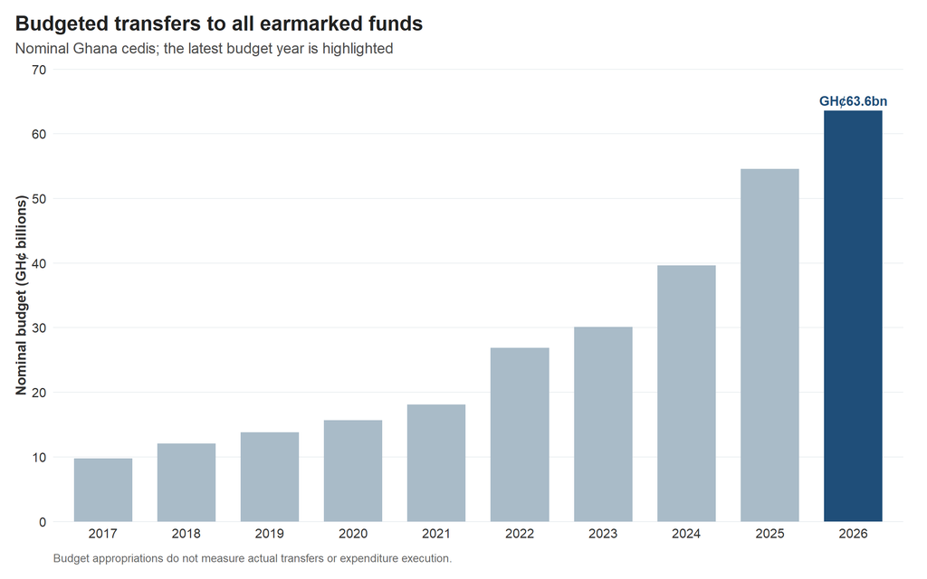

```r
all_transfers_amount_plot <- ggplot(
  all_transfers_amount_data,
  aes(x = factor(year), y = budget_ghc_billions, fill = year_role)
) +
  geom_col(width = 0.70) +
  geom_text(
    data = all_transfers_amount_data %>%
      filter(year_role == "Latest year"),
    aes(label = latest_value_label),
    vjust = -0.55,
    colour = broad_navy,
    fontface = "bold",
    size = 4.4
  ) +
  scale_fill_manual(
    values = c("Earlier year" = broad_light, "Latest year" = broad_navy)
  ) +
  scale_y_continuous(
    limits = c(0, common_amount_y_max_billions),
    breaks = breaks_pretty(n = 5),
    labels = label_number(accuracy = 1),
    expand = expansion(mult = c(0, 0))
  ) +
  labs(
    title = "Budgeted transfers to all earmarked funds",
    subtitle = "Nominal Ghana cedis; the latest budget year is highlighted",
    x = NULL,
    y = "Nominal budget (GH¢ billions)",
    caption = "Budget appropriations do not measure actual transfers or expenditure execution."
  ) +
  theme_ghana

write_plot_csv(
  all_transfers_amount_data,
  "06_ghana_all_earmarked_transfers_amount"
)
save_plot(
  all_transfers_amount_plot,
  "06_ghana_all_earmarked_transfers_amount",
  width = 12,
  height = 7.5
)
all_transfers_amount_plot
```